# Ford GoBike System Data Exploration

Ford GoBike data set includes information about individual rides made in a bike-sharing system covering the greater San Francisco Bay area. Data contains information about Trips, Stations, Bikes and Users.

## Dataset overview

The original dataset contains 183,412 trip. Features are realated to trip, statation, bike and user as following:

- Trip (duration, start & end time)
- Station (start & end station id, name, geographic coordinates)
- Bike id
- User (Customer or subscriber, gender, birth year)

After wrangling the data, only 175,147 trip will be considered in the analysis. New features have been extraction to the support the analysis, as following:

- Trip start hour
- Trip duration in minutes
- Member age
- Trip was at daylight or night

## Distribution of Trip duration

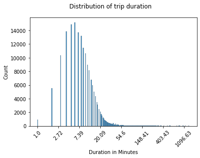

```python
## there's a long tail in the distribution, so let's put it on a log scale instead

# create log_duration_min in the dataframe to use it
df['log_duration_min']= df['duration_min'].apply(np.log)

plt.figure(new_figId()).suptitle('Distribution of trip duration')
hst= sb.histplot(data = df, x = 'log_duration_min');
hst.set_xticklabels([round(np.exp(i),2) for i in plt.xticks()[0]], rotation=45);
hst.set(xlabel='Duration in Minutes', ylabel='Count')



visualize(hst);
```

## Distribution of Member ages

The distribution of age shows that 99.5% of the trips took place by members under 70. Most member ages are between 27 and 39, full range of ages from 18 to 67, and average age is 34.

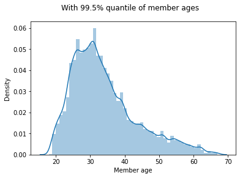

```python
# visualize 99.5% quantile of member ages
dst_995 = plt.figure(new_figId())
dst_995.suptitle('With 99.5% quantile of member ages')
sb.distplot(df[df.member_age < df.member_age.quantile(.995)].member_age).set(xlabel='Member age');

visualize(  dst_995 )
```

## Distribution of User Gender and Type

Trips by Males are around 75%, 24% by Females and 2% by Other. Also, Trips by Subscriber are around 90% and 10% by Customer.

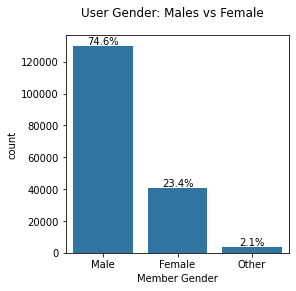

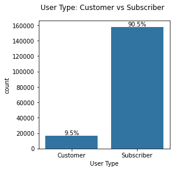

```python
gender_fig = plt.figure(new_figId(),figsize=(4,4));
gender_fig.suptitle('User Gender: Males vs Female ')
ax = sb.countplot(data= df, x= 'member_gender', color = color_palette);
ax.set(xlabel='Member Gender')
set_countplot_percentage(df['user_type'], ax)

day_night_fig = plt.figure(new_figId(),figsize=(4,4));
day_night_fig.suptitle('User Type: Customer vs Subscriber')
ax = sb.countplot(data= df, x= 'user_type', color = color_palette);
ax.set(xlabel='User Type')
set_countplot_percentage(df['user_type'], ax)

visualize(gender_fig, day_night_fig)
```

## Trips count for Gender and User Type every day of the week

Trip counts varies with day of week, where week days trip counts are much more than trips in week ends. Male trips are more than female, Subscriber trips are more that Customer.

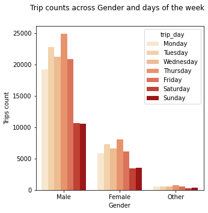

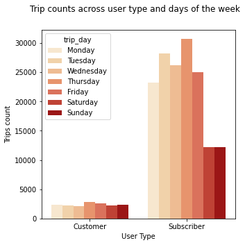

```python
plt.figure(new_figId(), figsize=(5,5)).suptitle('Trip counts across Gender and days of the week')
mg_td= sb.countplot(data= df, x= 'member_gender', hue='trip_day', palette= 'OrRd')
mg_td.set(xlabel='Gender', ylabel='Trips count');

plt.figure(new_figId(), figsize=(5,5)).suptitle('Trip counts across user type and days of the week')
ut_td = sb.countplot(data= df, x= 'user_type', hue='trip_day', palette= 'OrRd')
ut_td.set(xlabel='User Type', ylabel='Trips count');

visualize(mg_td, ut_td)
```

## Trips count for Age group, Gender and User Type for every day of the week

The highest number of trips is taking place on working days by Male Subscribers of age between 26 and 35, followed by trips at the same times by Male Subscribers of age between 36 and 45

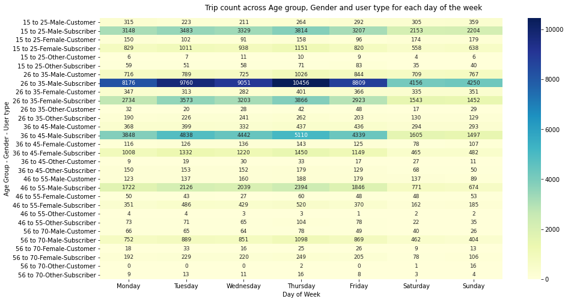

```python
#calculate age groups from 15 to 70 years each group 10 years

df['age_bins'] = pd.cut(x=df.member_age, bins=[15, 25, 35, 45, 55, 70],
                        labels=['15 to 25', '26 to 35', '36 to 45', '46 to 55', '56 to 70'])

ga = df.groupby(['age_bins', 'member_gender', 'user_type', 'trip_day'])['duration_min'].count().reset_index(name="count")
ga= ga.pivot_table(index=['age_bins', 'member_gender', 'user_type'], columns="trip_day", values='count', aggfunc = np.sum)

plt.figure(new_figId(), figsize=(15, 8)).suptitle('Trip count across Age group, Gender and user type for each day of the week', y=0.92)
#f4.suptitle('Number of trips for Age group vs. Gender vs. User type vs. Day of Week')
g = sb.heatmap(ga, fmt='d',  annot=True, cmap='YlGnBu', annot_kws={'size': 9})
g.set(xlabel='Day of Week', ylabel='Age Group - Gender - User type')
g.set_yticklabels(g.get_yticklabels(), rotation = 0, fontsize = 10)
visualize(g)
```

## Trip duration by Age group and User type/Gender

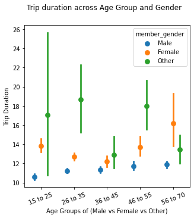

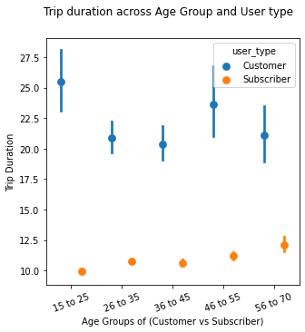

```python
plt.figure(new_figId(), figsize=(5,5)).suptitle('Trip duration across Age Group and Gender')
d_g = sb.pointplot(data =df, x = 'age_bins', y = 'duration_min', hue = 'member_gender', linestyles = '', dodge = 0.4)
d_g.set(xlabel='Age Groups of (Male vs Female vs Other)', ylabel='Trip Duration')
d_g.set_xticklabels(labels= plt.xticks()[1], rotation=20)

plt.figure(new_figId(), figsize=(5,5)).suptitle('Trip duration across Age Group and User type')
d_ut = sb.pointplot(data =df, x = 'age_bins', y = 'duration_min', hue = 'user_type', linestyles = '', dodge = 0.4)
d_ut.set(xlabel='Age Groups of (Customer vs Subscriber)', ylabel='Trip Duration')
d_ut.set_xticklabels(labels= plt.xticks()[1], rotation=20)

visualize( d_g, d_ut)
```